# Analysis of Highest Degree Earned and Religious Service Attendence

**Chris Sweeney, October 17th 2014**

**Introduction**

This project is a chi-square independence analsysis of the affect of Highest Degree Earned on Religious Service Attendence. It explores any dependencies between education and religious observance. It is of interest to see if there is any effect of education on religious practice in the population sampled.

**Data**

Data were collected via questionerres for the General Social Survey over a period of time from 1972-2012 Cases are indivial respondents to the questionaire. The variable we are reviewing are ‘attend’ (for religious service attendence) and ‘degree’ (for highest degree attained). The are both categorical variables. We are working with 46267 observations of 2 variables, the response variable (attend) has 8 levels and the explanatory variable (degree) has 5 levels. The GSS data are a volunteer-biased, observational study that is conducted over a period of years, each year may or may no contain the same questions/data elements. Additionally, the number of respondents per question vary across years. Generalization to a wider population is not possible due to these and other confounding issue (ie socail attitudes toward religion changing over time, individual participation varies over time, geographic and regional differences in attendence).

**Exploratory Analysis**

The following code loads and prepares the data.

```r
setInternet2()
load(url("http://bit.ly/dasi_gss_data"))
#just columns of interest, gss$year, gss$degree and gss$attend
mygss <-gss[c(2,12,32)]
#remove rows with NAs in either column
testgss <-mygss[!is.na(mygss[,1])&!is.na(mygss[,2])&!is.na(mygss[,3]),]
#droplevels
testgss <- droplevels(testgss)
```

Create a 2 dimension contigency table

```r
t2 = table(testgss$degree, testgss$attend) # 2-D contingency table
#shorten the names for the graphs
colnames(t2) <- c("<yr","1/yr","svrl/yr","1/mn","svrl/mn","< evry wk","evry wk","> evry wk")
rownames(t2) <-c("<HS","HS","JC","Bach","Grad")
```

A look at the data.

```r
#EDA
summary(testgss)
```

```
##       year                 degree                   attend
##  Min.   :1972   Lt High School: 9379   Every Week      :11162
##  1st Qu.:1982   High School   :24279   Once A Year     : 7384
##  Median :1991   Junior College: 2610   Sevrl Times A Yr: 7081
##  Mean   :1992   Bachelor      : 6774   2-3X A Month    : 4974
##  3rd Qu.:2002   Graduate      : 3225   Lt Once A Year  : 4276
##  Max.   :2012                          More Thn Once Wk: 4257
##                                        (Other)         : 7133
```

**Bar Plot of Percentage of counts of Degree versus Attend**

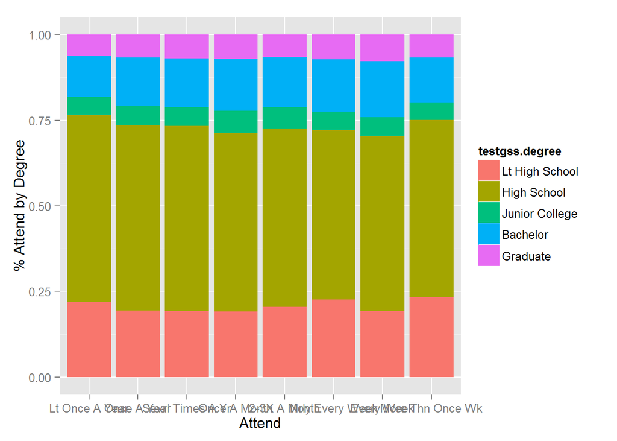

```r
setInternet2()
install.packages("ggplot2")
library("ggplot2")
t <-data.frame(testgss$attend,testgss$degree)
ggplot(t, aes(x = testgss.attend)) + ylab("% Attend by Degree") + xlab("Attend") + geom_bar(aes(fill = testgss.degree), position = 'fill') + coord_fixed(ratio=7)
```

**Association table of Residuals**

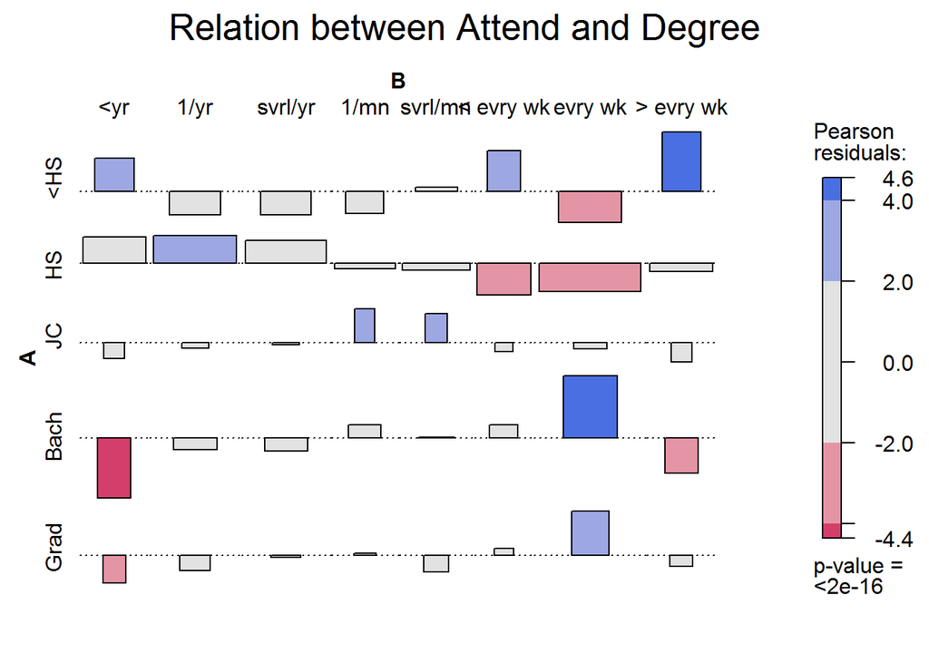

```r
setInternet2()
install.packages("vcd")
library("vcd")
assoc(t2,shade=TRUE, main="Relation between Attend and Degree")
```

**Inference**

**State hypotheses**

**HO** Highest Degree Attained and Religious Service Attendence are independent. Attendence does not vary by education level.

This data meets the conditions for chi-squred analysis of differences. The observations are independent, there is one row per respondent. The sampling is random without replavement with n <10% of the population. Each case contributes to only one cell of the dependency table, and each cell of the dependency table has at least 5 cases.

**Data Analysis**

**Using R to call a chisq.test**

```r
chisq.test(t2) # Pearson Chi-Square test
```

```
##
##  Pearson's Chi-squared test
##
## data:  t2
## X-squared = 150.5, df = 28, p-value < 2.2e-16
```

**Display the contigency table of observed counts**

```r
chisq.test(t2)$observed
```

```
##
##         <yr 1/yr svrl/yr 1/mn svrl/mn < evry wk evry wk > evry wk
##   <HS   938 1432    1371  765    1018       710    2155       990
##   HS   2335 4000    3818 2082    2586      1550    5702      2206
##   JC    223  408     396  263     316       168     618       218
##   Bach  517 1054    1006  609     730       479    1819       560
##   Grad  263  490     490  281     324       226     868       283
```

**Display the contigency table of expected counts**

```r
chisq.test(t2)$expected
```

```
##
##           <yr   1/yr svrl/yr   1/mn svrl/mn < evry wk evry wk > evry wk
##   <HS   866.8 1496.8  1435.4  810.9  1008.3     635.1  2262.7     863.0
##   HS   2243.9 3874.8  3715.8 2099.0  2610.1    1644.1  5857.4    2233.9
##   JC    241.2  416.5   399.5  225.6   280.6     176.7   629.7     240.1
##   Bach  626.1 1081.1  1036.7  585.6   728.2     458.7  1634.2     623.3
##   Grad  298.1  514.7   493.6  278.8   346.7     218.4   778.0     296.7
```

**Subtract the observed matrix from the expected matrix and list the differences**

```r
round(chisq.test(t2)$expected, digits=2) - round(chisq.test(t2)$observed, digits=2)
```

```
##
##            <yr    1/yr svrl/yr    1/mn svrl/mn < evry wk evry wk > evry wk
##   <HS   -71.19   64.85   64.42   45.86   -9.70    -74.89  107.70   -127.04
##   HS    -91.13 -125.18 -102.19   17.03   24.15     94.07  155.35     27.90
##   JC     18.22    8.54    3.45  -37.35  -35.41      8.74   11.67     22.14
##   Bach  109.05   27.10   30.74  -23.36   -1.75    -20.29 -184.76     63.27
##   Grad   35.05   24.70    3.57   -2.18   22.71     -7.62  -89.96     13.73
```

**Inference and Conclusion**

H-0: Response and explanatory variables are independent. Attendance does not vary by education level. H-A: Response and explanatory variables are dependent. Attendance does vary by education.

With a p-value from the Chi-squared test < 2.2e-16 we have strong evidence to reject the null hypothesis that religious service attendance does not vary by education level. This is graphically displayed in the bar plot in the Exploratory Data Analysis section and also confirmed in the contingency table that displays the difference in values between observed and expected results. However, while we can infer some relationship exists between degree and attendance, we cannot conclude that it is a sole or primary explanation for differences between Religious Service Attendance.

**Citations**

Inference function from DASI Coursera website http://s3.amazonaws.com/assets.datacamp.com/course/dasi/inference.Rdata

DASI project RMD Template http://bit.ly/dasi_project_template

R programming Essential Functions http://forums.psy.ed.ac.uk/R/P01582/essential-12/

R Tutorials Chi Square Test of Independence http://ww2.coastal.edu/kingw/statistics/R-tutorials/independ.html

R Library Matrices and Matrix Computations in R http://www.ats.ucla.edu/stat/r/library/matrix_alg.htm

Stacked bar chart as percentage of counts http://stackoverflow.com/questions/3619067/stacked-bar-chart-in-r-ggplot2-with-y-axis-and-bars-as-percentage-of-counts?rq=1

Association Plots http://www.statmethods.net/advgraphs/mosaic.html http://www.r-project.org/conferences/DSC-2003/Proceedings/MeyerEtAl.pdf

**Data Citation**

Smith, Tom W., Michael Hout, and Peter V. Marsden. General Social Survey, 1972-2012 [Cumulative File]. ICPSR34802-v1. Storrs, CT: Roper Center for Public Opinion Research, University of Connecticut /Ann Arbor, MI: Inter-university Consortium for Political and Social Research [distributors], 2013-09-11. doi:10.3886/ICPSR34802.v1

Persistent URL: http://doi.org/10.3886/ICPSR34802.v1

**Appendix of Data**

```r
print(testgss[1:50, ])
```

```
##    year         degree           attend
## 1  1972       Bachelor      Once A Year
## 2  1972 Lt High School       Every Week
## 3  1972    High School     Once A Month
## 6  1972    High School      Once A Year
## 7  1972    High School       Every Week
## 9  1972    High School Sevrl Times A Yr
## 10 1972    High School More Thn Once Wk
## 11 1972    High School       Every Week
## 12 1972 Lt High School       Every Week
## 13 1972 Lt High School       Every Week
## 14 1972 Lt High School       Every Week
## 15 1972 Lt High School More Thn Once Wk
## 16 1972    High School     2-3X A Month
## 17 1972    High School       Every Week
```

[output cut: 36 more lines]

Chris Sweeney, October 17th 2014